# Scanner tool for SuS: Revolutions in Biomedicine

28/05/2021

## Monitoring emerging variants

As part of the UK pandemic response, we develop methods to identify and monitor emerging variants of interest. Your job today is to look at clusters of interest, including specific lineages or lineage and mutation combinations, and report on growth rates. We wil look at outputs from the scanning tool designed for Public Health England (PHE) as part of the SARS-CoV-2 pandemic response to monitor emerging variants of interest or concern.

#### PHE situation report

Imagine the date is the 28th of May, 2021. PHE has requested a situation report on the top 20 growth clusters of interest, as well as clusters associated to mutations **S:L452R**, **S:K417N**, and **S:Q677H**. This report should be about three pages in length, and include figures or tables from the scanning tool as part of the report. Factors to consider when writing your report:

1. Which lineages are the highest growth rate lineages?
2. Where are these lineages occuring in the population? (Use google maps to look up UK locations if uncertain)
3. How does their growth look over time? What about their frequency? How many LTLAs do we see them in?
4. How do age distributions look in these lineages of interest?
5. What about vaccinations? What information do we have on vaccinations?
6. Do we see any mutations of interest or concern (to be discussed further in the mutations section below)?
7. How might current non-pharmaceutical interventions impact growth rates (remember the date is 28/05/2021)?

**N.B** You will include this report as part of the summative SuS Revolutions in Biomedicine portfolio. You are not expected to complete this report in the practical period, so please take the time to discuss outputs with your classmates as you work through the practical together.

#### Lineage nomenclature

Table 1. provides a reference of lineages of interest or concern that you should consider looking at in the scanner outputs. Please note, all scanner outputs utlise the pangolin lineage nomenclature, but feel free to call these be either WHO, pangolin lineage nomenclature or VOC/VUI designation in your report write up.

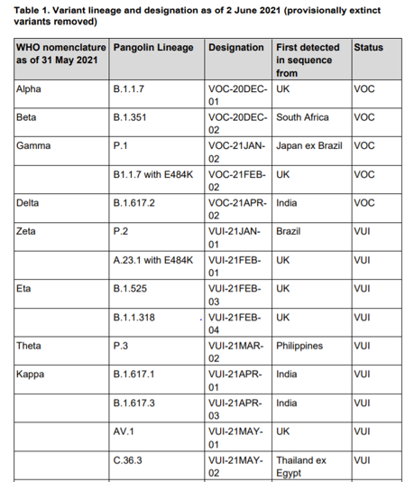